# *juede* and *zhidao* corpus study

# 1. Load Data

```r
data <- read.csv("../../data/childes/zhidao_juede_no_readings_combined.csv", header=TRUE) %>%
  filter(!grepl("Chang2/BookReading", file_name)) %>%
  select(!c("file_name", "speaker", "sentence"))

clean_data <- data %>%
  mutate(id=row_number(),
         across(c(sentence_type_e, sentence_type_g, sentence_type_c, sentence_type_j3, embedded_sentence_type_e, embedded_sentence_type_g, embedded_sentence_type_c, embedded_sentence_type_j3),
                ~ if_else(.x == "3 how/why", "2 wh_question", .x)),
         across(c(embedded_sentence_type_e, embedded_sentence_type_g, embedded_sentence_type_c, embedded_sentence_type_j3),
                ~ if_else(.x == "3 base-generated wh/polar", "3 base_position", .x)),
         across(c(subject_j1, subject_j2),
                ~ case_when(.x == "4 self_reference" ~ "1 first_person",
                            .x == "5 自己" ~ "5 ambiguous ziji",
                            TRUE ~ .x)))
```

# 2. Reliability

## 2.1 Type of matrix subject

```r
matrix_subject_reliability.data <- clean_data %>%
  select(c(subject_j1, subject_j2, id)) %>%
  # mutate(subject_j2 = if_else(subject_j2 == "", NA, subject_j2)) %>% # a more lenient criterion when change to NA
  pivot_longer(cols = c(subject_j1, subject_j2),
               names_to = "coder_id",
               values_to = "value") %>%
  pivot_wider(names_from = id,
              values_from = value) %>%
  select(-coder_id)

matrix_subject_reliability.data <- as.matrix(matrix_subject_reliability.data)
kripp.alpha(matrix_subject_reliability.data, method = "nominal")
```

```
##  Krippendorff's alpha
##
##  Subjects = 4300
##    Raters = 2
##     alpha = 0.97
```

## 2.2 Type of matrix sentence

```r
matrix_sentence_reliability.data <- clean_data %>%
  select(c(sentence_type_e, sentence_type_g, sentence_type_c, sentence_type_j3, id)) %>%
  pivot_longer(cols = c(sentence_type_e, sentence_type_g, sentence_type_c, sentence_type_j3),
               names_to = "coder_id",
               values_to = "value") %>%
  pivot_wider(names_from = id,
              values_from = value) %>%
  select(-coder_id)

matrix_sentence_reliability.data <- as.matrix(matrix_sentence_reliability.data)
kripp.alpha(matrix_sentence_reliability.data, method = "nominal")
```

```
##  Krippendorff's alpha
##
##  Subjects = 4300
##    Raters = 4
##     alpha = 0.896
```

An alternative way is to group matrix wh and polar questions into interrogatives. This makes the reliability score slightly lower (krippendorff’s alpha decreases from 0.896 to 0.893), since there is one less category label.

```r
matrix_sentence_reliability_alt.data <- clean_data %>%
  select(c(sentence_type_e, sentence_type_g, sentence_type_c, sentence_type_j3, id)) %>%
  mutate(
    across(sentence_type_e:sentence_type_j3, ~ if_else(.x %in% c("1 polar_question", "2 wh_question"), "interrogative", .x))
  ) %>%
  pivot_longer(cols = c(sentence_type_e, sentence_type_g, sentence_type_c, sentence_type_j3),
               names_to = "coder_id",
               values_to = "value") %>%
  pivot_wider(names_from = id,
              values_from = value) %>%
  select(-coder_id)

matrix_sentence_reliability_alt.data <- as.matrix(matrix_sentence_reliability_alt.data)
kripp.alpha(matrix_sentence_reliability_alt.data, method = "nominal")
```

```
##  Krippendorff's alpha
##
##  Subjects = 4300
##    Raters = 4
##     alpha = 0.893
```

## 2.3 Whether there is an embedded CP

Two annotators coded whether there is an CP or not. It is based on the linear order, so cases where the verb is in the tag are labeled as no CP, e.g., 今天会下雨，你知道吗？It will rain today, you know?

There are part of the *zhidao* data where the annotators further specify what type of embedded content it is if not a CP, which should be the second step. So here, we clean it up by grouping everything that is not labeled as a “2 CP,” including, for example “0 No”, “3 incomplete”, “4 NP” etc., into “0 No”.

```r
embedded_CP_reliability.data <- clean_data %>%
  mutate(embedded_CP_j1 = if_else(embedded_CP_j1 != "2 CP", "0 No", embedded_CP_j1),
         embedded_CP_j2 = if_else(embedded_CP_j2 != "2 CP", "0 No", embedded_CP_j2)) %>%
  select(c(embedded_CP_j1, embedded_CP_j2, id)) %>%
  pivot_longer(cols = c(embedded_CP_j1, embedded_CP_j2),
               names_to = "coder_id",
               values_to = "value") %>%
  pivot_wider(names_from = id,
              values_from = value) %>%
  select(-coder_id)

embedded_CP_reliability.data <- as.matrix(embedded_CP_reliability.data)
kripp.alpha(embedded_CP_reliability.data, method = "nominal")
```

```
##  Krippendorff's alpha
##
##  Subjects = 4300
##    Raters = 2
##     alpha = 0.94
```

Similar to before, we group everything that is not labeled as a “2 CP,” including, for example “0 No”, “3 incomplete”, “4 NP” etc., into “0 No”

```r
embedded_CP_reliability_alt.data <- clean_data %>%
  mutate(embedded_CP_j1 = if_else(embedded_CP_j1 != "2 CP", "0 No", embedded_CP_j1),
         embedded_CP_j2 = if_else(embedded_CP_j2 != "2 CP", "0 No", embedded_CP_j2)) %>%
  mutate(embedded_CP_j1 = if_else(embedded_CP_j1 == "0 No" & embedded_content_j1 == "1 Adj", "2 CP", embedded_CP_j1),
         embedded_CP_j2 = if_else(embedded_CP_j2 == "0 No" & embedded_content_j2 == "1 Adj", "2 CP", embedded_CP_j2)) %>%
  select(c(embedded_CP_j1, embedded_CP_j2, id)) %>%
  pivot_longer(cols = c(embedded_CP_j1, embedded_CP_j2),
               names_to = "coder_id",
               values_to = "value") %>%
  pivot_wider(names_from = id,
              values_from = value) %>%
  select(-coder_id)

embedded_CP_reliability_alt.data <- as.matrix(embedded_CP_reliability_alt.data)
kripp.alpha(embedded_CP_reliability_alt.data, method = "nominal")
```

```
##  Krippendorff's alpha
##
##  Subjects = 4300
##    Raters = 2
##     alpha = 0.953
```

## 2.4 Type of embedded content

When the embedded content is not a CP, the two annotators further coded whether it is an NP, incomplete, no CP, or in a relative clause (e.g., 觉得/知道的东西 juede/zhidao + de + NP).

```r
embedded_content_reliability.data <- clean_data %>%
  mutate(embedded_content_j1 = if_else(embedded_CP_j1 == "2 CP", "2 CP", embedded_content_j1),
        embedded_content_j2 = if_else(embedded_CP_j2 == "2 CP", "2 CP", embedded_content_j2)) %>%
  select(c(embedded_content_j1, embedded_content_j2, id)) %>%
  pivot_longer(cols = c(embedded_content_j1, embedded_content_j2),
               names_to = "coder_id",
               values_to = "value") %>%
  pivot_wider(names_from = id,
              values_from = value) %>%
  select(-coder_id)

embedded_content_reliability.data <- as.matrix(embedded_content_reliability.data)
kripp.alpha(embedded_content_reliability.data, method = "nominal")
```

```
##  Krippendorff's alpha
##
##  Subjects = 4300
##    Raters = 2
##     alpha = 0.923
```

Given that there is inconsistency when the embedded content is only an adjective, we are combining cases where annotators indicated “0 No CP” for whether there is an embedded CP AND “1 Adj” for the type of embedded clause to “2 CP”. This does not change the reliability score.

Another category that the two annotators disagree is whether the verb is used in a relative clause (RC). Combining the RC cases into “0 No” slightly increases the reliability score (krippendorff’s alpha increases from 0.923 to 0.929).

Since there are not a lot of cases where the embedded content is an NP, incomplete or part of a relative clause, we can group them into a category “others”, and the realiability score increases slightly (krippendorff’s alpha increases from 0.923 to 0.929).

```r
embedded_content_reliability_alt.data <- clean_data %>%
  mutate(embedded_CP_j1 = if_else(embedded_CP_j1 == "0 No" & embedded_content_j1 == "1 Adj", "2 CP", embedded_CP_j1),
         embedded_CP_j2 = if_else(embedded_CP_j2 == "0 No" & embedded_content_j2 == "1 Adj", "2 CP", embedded_CP_j2)) %>%
  mutate(embedded_content_j1 = if_else(embedded_CP_j1 == "2 CP", "2 CP", embedded_content_j1),
        embedded_content_j2 = if_else(embedded_CP_j2 == "2 CP", "2 CP", embedded_content_j2)) %>%
  # mutate(embedded_content_j1 = case_when(embedded_CP_j1 == "2 CP" ~ "2 CP",
  #                                        embedded_CP_j1 == "0 No" & embedded_content_j1 == "4 RC的" ~ "0 CP",
  #                                        TRUE ~ embedded_content_j1),
  #        embedded_content_j2 = case_when(embedded_CP_j2 == "2 CP" ~ "2 CP",
  #                                        embedded_CP_j2 == "0 No" & embedded_content_j2 == "4 RC的" ~ "0 CP",
  #                                        TRUE ~ embedded_content_j2)) %>%
  mutate(embedded_content_j1 = if_else(embedded_content_j1 %in% c("2 NP", "3 Incomplete", "4 RC的"), "others", embedded_content_j1),
         embedded_content_j2 = if_else(embedded_content_j2 %in% c("2 NP", "3 Incomplete", "4 RC的"), "others", embedded_content_j2)) %>%
  select(c(embedded_content_j1, embedded_content_j2, id)) %>%
  pivot_longer(cols = c(embedded_content_j1, embedded_content_j2),
               names_to = "coder_id",
               values_to = "value") %>%
  pivot_wider(names_from = id,
              values_from = value) %>%
  select(-coder_id)

embedded_content_reliability_alt.data <- as.matrix(embedded_content_reliability_alt.data)
kripp.alpha(embedded_content_reliability_alt.data, method = "nominal")
```

```
##  Krippendorff's alpha
##
##  Subjects = 4300
##    Raters = 2
##     alpha = 0.929
```

## 2.5 Type of embedded sentence

```r
embedded_sentence_reliability.data <- clean_data %>%
  select(c(embedded_sentence_type_e, embedded_sentence_type_g, embedded_sentence_type_c, embedded_sentence_type_j3, id)) %>%
  mutate(
    across(embedded_sentence_type_e:embedded_sentence_type_j3, ~ if_else(.x == "", "NONE", .x))
  ) %>%
  pivot_longer(cols = c(embedded_sentence_type_e, embedded_sentence_type_g, embedded_sentence_type_c, embedded_sentence_type_j3),
               names_to = "coder_id",
               values_to = "value") %>%
  pivot_wider(names_from = id,
              values_from = value) %>%
  select(-coder_id)

embedded_sentence_reliability.data <- as.matrix(embedded_sentence_reliability.data)
kripp.alpha(embedded_sentence_reliability.data, method = "nominal")
```

```
##  Krippendorff's alpha
##
##  Subjects = 4300
##    Raters = 4
##     alpha = 0.924
```

## 2.6 Negation

```r
negation_reliability.data <- clean_data %>%
  select(c(matrix_negation_e, matrix_negation_g, matrix_negation_j1, id)) %>%
  pivot_longer(cols = c(matrix_negation_e, matrix_negation_g, matrix_negation_j1),
               names_to = "coder_id",
               values_to = "value") %>%
  pivot_wider(names_from = id,
              values_from = value) %>%
  select(-coder_id)

negation_reliability.data <- as.matrix(negation_reliability.data)
kripp.alpha(negation_reliability.data, method = "nominal")
```

```
##  Krippendorff's alpha
##
##  Subjects = 4300
##    Raters = 3
##     alpha = 0.996
```

## 2.7 Sentence-final particle *ma*

```r
ma_reliability.data <- clean_data %>%
  select(c(ma_particle_e, ma_particle_j, ma_particle_p, id)) %>%
  pivot_longer(cols = c(ma_particle_e, ma_particle_j, ma_particle_p),
               names_to = "coder_id",
               values_to = "value") %>%
  pivot_wider(names_from = id,
              values_from = value) %>%
  select(-coder_id)

negation_reliability.data <- as.matrix(negation_reliability.data)
kripp.alpha(negation_reliability.data, method = "nominal")
```

```
##  Krippendorff's alpha
##
##  Subjects = 4300
##    Raters = 3
##     alpha = 0.996
```

# 3. Distrubtions

For the distribution, we are only using data that the two coders agreed on.

## 3.1 matrix subject

```r
matrix_subject.data <- clean_data %>%
  select(c(id, verb, subject_j1, subject_j2)) %>%
  mutate(agreement = if_else(subject_j1 == subject_j2, "same", "diff")) %>%
  filter(agreement == "same") %>%
  select(!c(agreement, subject_j1)) %>%
  rename(subject_type = subject_j2)

matrix_subject_summary <- matrix_subject.data %>%
  group_by(verb, subject_type) %>%
  summarize(count = n()) %>%
  ungroup() %>%
  group_by(verb) %>%
  mutate(percent = count/sum(count) * 100) %>%
  ungroup()
```

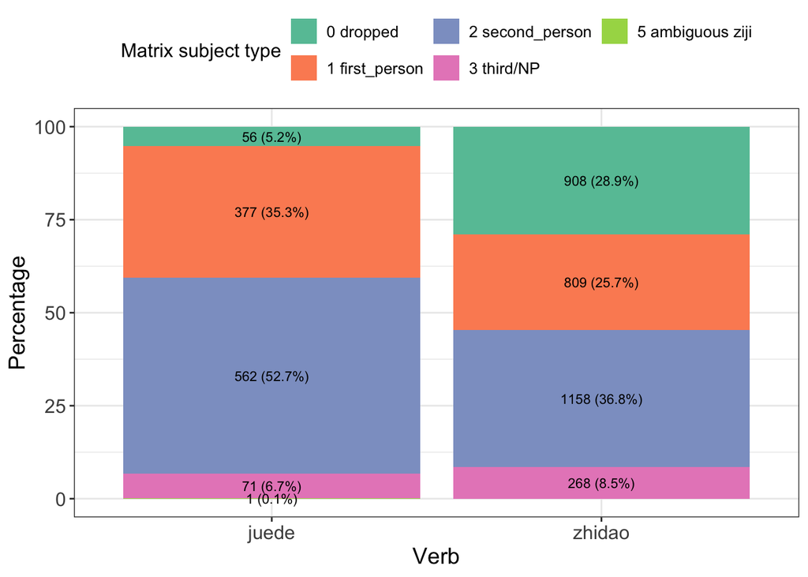

```r
ggplot(matrix_subject_summary,
       aes(x=verb,
           y=percent,
           fill=subject_type)) +
  geom_col()+
  geom_text(aes(label=paste0(count, " (", round(percent, 1), "%)")),
            position = position_stack(vjust = 0.5),
            color = "black",
            size = 3)+
  # geom_label(aes(label=count,
  #                group = subject_type),
  #           position = position_stack(vjust = 0.5),
  #           fill = "white",
  #           color = "black",
  #           label.size = 0.3,
  #           label.padding = unit(0.15, "lines"),
  #           size = 3)+
  theme_bw()+
  scale_fill_brewer(palette = "Set2",
                    name="Matrix subject type",
                    guide=guide_legend(nrow=2)) +
  theme(legend.position = "top",
        axis.title.x = element_text(size = 14),
        axis.text.x = element_text(size = 12),
        axis.text.y = element_text(size = 12),
        strip.text = element_text(size = 12),
        strip.text.x = element_text(size=12),
        legend.text = element_text(size=10),
        legend.title = element_text(size=12),
        axis.title.y = element_text(size = 14))+
  labs(x="Verb",
       y="Percentage")
```

## 3.2 matrix sentence

This is based on the interpretation of the sentence. Thus, 1 polar_question and 2 wh_question categories include cases where it is a matrix polar/wh_question based on its sentence structure (e.g., A-not-A at the matrix level as in 觉不觉得 jue-bu-juede or 知不知道 zhi-bu-zhidao, or wh-phrases at the matrix level as in 怎么/为什么觉得/知道 zenme/weishenme juede/zhidao “how/why does [someone] think/know) and cases where the sentence has a declarative sentence structure (”superficially declarative”) but contains a polar-construction/wh-phrase in the embedded clause that takes a matrix scope (which is sometimes referred to as “potentially interrogatives”).

```r
matrix_sentence.data <- clean_data %>%
  select(c(id, verb, sentence_type_e, sentence_type_g, sentence_type_c, sentence_type_j3)) %>%
  rowwise() %>%
  mutate(
    n_filled = sum(c_across(sentence_type_e:sentence_type_j3) != "" & !is.na(c_across(sentence_type_e:sentence_type_j3))), # cases where only 1 coder considers it incomplete and the other considers it complete
    agreement = {
      vals <- c_across(sentence_type_e:sentence_type_j3)
      vals <- vals[vals != "" & !is.na(vals)]
      if_else(n_filled == 2 && length(unique(vals)) == 1, "same", "diff")
      },
    agreed_sentence_type = {
      vals <- c_across(sentence_type_e:sentence_type_j3)
      vals <- vals[vals != "" & !is.na(vals)]
      vals[1]
    }
    ) %>%
  ungroup() %>%
  filter(agreement == "same") %>%
  select(!c(agreement, sentence_type_e, sentence_type_g, sentence_type_c, sentence_type_j3, n_filled)) %>%
  rename(matrix_sentence_type = agreed_sentence_type)

matrix_sentence_summary <- matrix_sentence.data %>%
  group_by(verb, matrix_sentence_type) %>%
  summarize(count = n()) %>%
  ungroup() %>%
  group_by(verb) %>%
  mutate(percent = count/sum(count) * 100) %>%
  ungroup()
```

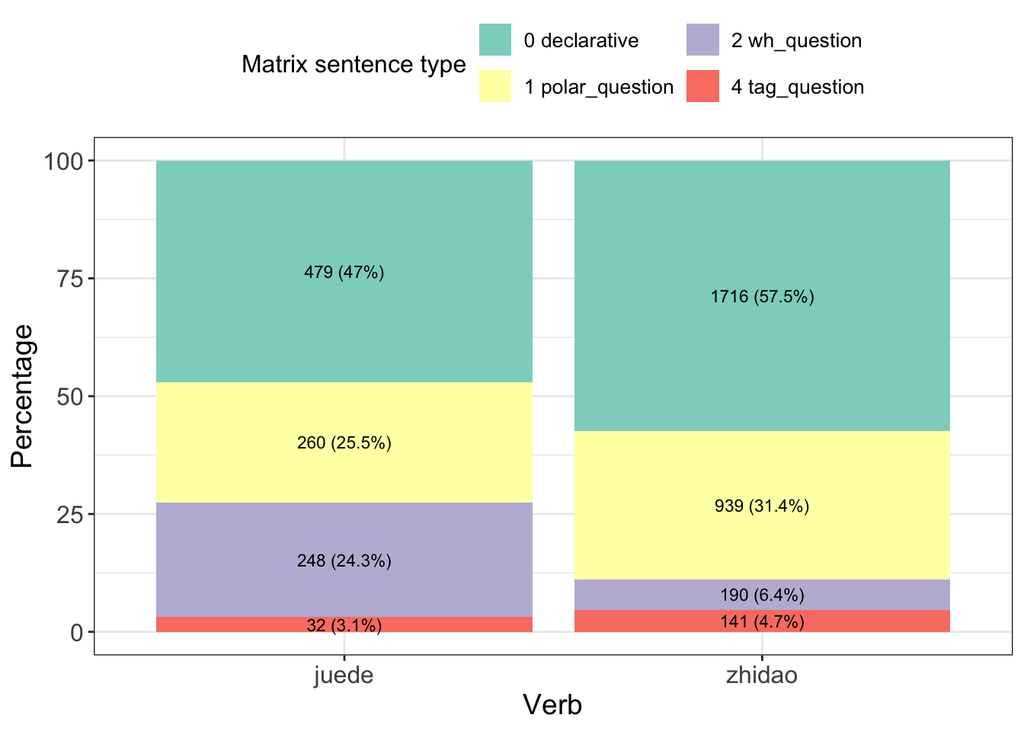

```r
ggplot(matrix_sentence_summary,
       aes(x=verb,
           y=percent,
           fill=matrix_sentence_type)) +
  geom_col()+
  geom_text(aes(label=paste0(count, " (", round(percent, 1), "%)")),
            position = position_stack(vjust = 0.5),
            color = "black",
            size = 3)+
  theme_bw()+
  scale_fill_brewer(palette = "Set3",
                    name="Matrix sentence type",
                    guide=guide_legend(nrow = 2)) +
  theme(legend.position = "top",
        axis.title.x = element_text(size = 14),
        axis.text.x = element_text(size = 12),
        axis.text.y = element_text(size = 12),
        strip.text = element_text(size = 12),
        strip.text.x = element_text(size=12),
        legend.text = element_text(size=10),
        legend.title = element_text(size=12),
        axis.title.y = element_text(size = 14))+
  labs(x="Verb",
       y="Percentage")
```

## 3.3 type of embedded content

```r
embedded_content.data <- clean_data %>%
  mutate(embedded_CP_j1 = if_else(embedded_CP_j1 == "0 No" & embedded_content_j1 == "1 Adj", "2 CP", embedded_CP_j1),
         embedded_CP_j2 = if_else(embedded_CP_j2 == "0 No" & embedded_content_j2 == "1 Adj", "2 CP", embedded_CP_j2)) %>%
   mutate(embedded_content_j1 = if_else(embedded_CP_j1 == "2 CP", "1 CP", embedded_content_j1),
        embedded_content_j2 = if_else(embedded_CP_j2 == "2 CP", "1 CP", embedded_content_j2)) %>%
  mutate(embedded_content_j1 = if_else(embedded_content_j1 %in% c("2 NP", "3 Incomplete", "4 RC的"), "others", embedded_content_j1),
         embedded_content_j2 = if_else(embedded_content_j2 %in% c("2 NP", "3 Incomplete", "4 RC的"), "others", embedded_content_j2)) %>%  # grouping NP, incomplete and RC together because they are rare
  select(c(id, verb, embedded_content_j1, embedded_content_j2)) %>%
  mutate(agreement = if_else(embedded_content_j1 == embedded_content_j2, "same", "diff")) %>%
  filter(agreement == "same") %>%
  select(!c(agreement, embedded_content_j1)) %>%
  rename(embedded_content_type = embedded_content_j2)

embedded_content_summary <- embedded_content.data %>%
  group_by(verb, embedded_content_type) %>%
  summarize(count = n()) %>%
  ungroup() %>%
  group_by(verb) %>%
  mutate(percent = count/sum(count) * 100) %>%
  ungroup()
```

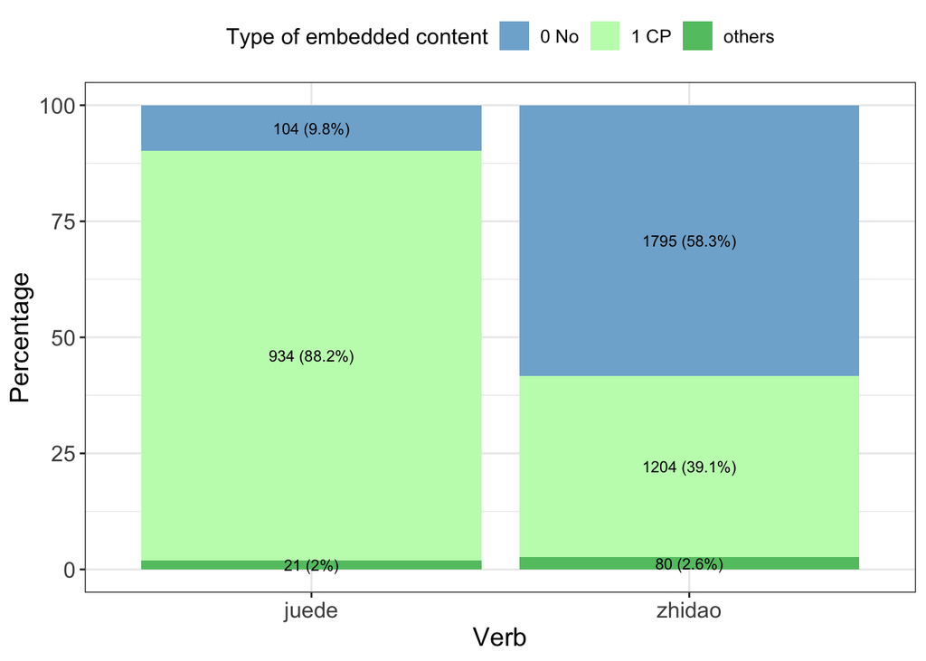

```r
ggplot(embedded_content_summary,
       aes(x=verb,
           y=percent,
           fill=embedded_content_type)) +
  geom_col()+
  geom_text(aes(label=paste0(count, " (", round(percent, 1), "%)")),
            position = position_stack(vjust = 0.5),
            color = "black",
            size = 3)+
  theme_bw()+
  scale_fill_manual(values = c("0 No" = "#80B1D3",
                               "1 CP" = "#C2F9BB",
                               "others" = "#62C370"),
                    name="Type of embedded content") +
  theme(legend.position = "top",
        axis.title.x = element_text(size = 14),
        axis.text.x = element_text(size = 12),
        axis.text.y = element_text(size = 12),
        strip.text = element_text(size = 12),
        strip.text.x = element_text(size=12),
        legend.text = element_text(size=10),
        legend.title = element_text(size=12),
        axis.title.y = element_text(size = 14))+
  labs(x="Verb",
       y="Percentage")
```

## 3.4 embedded sentence

“3 base position” includes cases where the a matrix sentence is superifically declarative but contains a polar-construction/wh-phrase in the embedded clause that takes a matrix scope (which is sometimes referred to as “potentially interrogatives”).

```r
embedded_sentence.data <- clean_data %>%
  select(c(id, verb, embedded_sentence_type_e, embedded_sentence_type_g, embedded_sentence_type_c, embedded_sentence_type_j3)) %>%
  mutate(
    across(embedded_sentence_type_e:embedded_sentence_type_j3, ~ if_else(.x == "", "NONE", .x))
  ) %>%
  rowwise() %>%
  mutate(
    agreement = {
      vals <- c_across(embedded_sentence_type_e:embedded_sentence_type_j3)
      vals <- vals[!is.na(vals)]
      if_else(length(unique(vals)) == 1, "same", "diff")
    },
    agreed_embedded_sentence_type = {
      vals <- c_across(embedded_sentence_type_e:embedded_sentence_type_j3)
      vals <- vals[!is.na(vals)]
      if_else(agreement == "same", vals[1], NA_character_)
    }
  ) %>%
  ungroup() %>%
  filter(agreement == "same") %>%
  select(!c(agreement, embedded_sentence_type_e, embedded_sentence_type_g, embedded_sentence_type_c, embedded_sentence_type_j3)) %>%
  rename(embedded_sentence_type = agreed_embedded_sentence_type)

embedded_sentence_summary <- embedded_sentence.data %>%
  group_by(verb, embedded_sentence_type) %>%
  summarize(count = n()) %>%
  ungroup() %>%
  group_by(verb) %>%
  mutate(percent = count/sum(count) * 100) %>%
  ungroup()
```

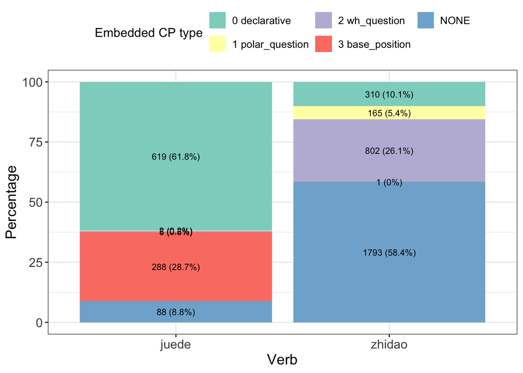

```r
ggplot(embedded_sentence_summary,
       aes(x=verb,
           y=percent,
           fill=embedded_sentence_type)) +
  geom_col()+
  geom_text(aes(label=paste0(count, " (", round(percent, 1), "%)")),
            position = position_stack(vjust = 0.5),
            color = "black",
            size = 3)+
  theme_bw()+
  scale_fill_brewer(palette = "Set3",
                    name="Embedded CP type",
                    guide=guide_legend(nrow = 2)) +
  theme(legend.position = "top",
        axis.title.x = element_text(size = 14),
        axis.text.x = element_text(size = 12),
        axis.text.y = element_text(size = 12),
        strip.text = element_text(size = 12),
        strip.text.x = element_text(size=12),
        legend.text = element_text(size=10),
        legend.title = element_text(size=12),
        axis.title.y = element_text(size = 14))+
  labs(x="Verb",
       y="Percentage")
```

### 3.4.1 matrix and embedded sentence combined

Here we combined the annotations for matrix sentence type and embedded sentence type to analyze cases that are “potentially interrogative,” i.e., the matrix clause type is in either 1 polar_question or 2 wh_question category AND the embedded clause is labeled as 3 base_position.

```r
matrix_embedded_sentence.data <- clean_data %>%
  select(c(id, verb,
           sentence_type_e, sentence_type_g, sentence_type_c, sentence_type_j3,
           embedded_sentence_type_e, embedded_sentence_type_g, embedded_sentence_type_c, embedded_sentence_type_j3)) %>%
  mutate(
    across(embedded_sentence_type_e:embedded_sentence_type_j3, ~ if_else(.x == "", "NONE", .x))
  ) %>%
  rowwise() %>%
  mutate(
    matrix_n_filled = sum(c_across(sentence_type_e:sentence_type_j3) != "" & !is.na(c_across(sentence_type_e:sentence_type_j3))),
    matrix_agreement = {
      vals <- c_across(sentence_type_e:sentence_type_j3)
      vals <- vals[vals != "" & !is.na(vals)]
      if_else(matrix_n_filled == 2 && length(unique(vals)) == 1, "same", "diff")
    },
    embedded_agreement = {
      vals <- c_across(embedded_sentence_type_e:embedded_sentence_type_j3)
      vals <- vals[!is.na(vals)]
      if_else(length(unique(vals)) == 1, "same", "diff")
    },
    agreed_sentence_type = {
      vals <- c_across(sentence_type_e:sentence_type_j3)
      vals <- vals[vals != "" & !is.na(vals)]
      vals[1]
    },
    agreed_embedded_sentence_type = {
      vals <- c_across(embedded_sentence_type_e:embedded_sentence_type_j3)
      vals <- vals[!is.na(vals)]
      if_else(embedded_agreement == "same", vals[1], NA_character_)
    }
  ) %>%
  ungroup() %>%
  filter(matrix_agreement == "same" & embedded_agreement == "same") %>%
  select(!c(matrix_n_filled, matrix_agreement,sentence_type_e, sentence_type_g, sentence_type_c, sentence_type_j3,
            embedded_agreement, embedded_sentence_type_e, embedded_sentence_type_g, embedded_sentence_type_c, embedded_sentence_type_j3)) %>%
  rename(matrix_sentence_type = agreed_sentence_type,
         embedded_sentence_type = agreed_embedded_sentence_type)
```

```r
matrix_embedded_sentence_combined.data <- matrix_embedded_sentence.data %>%
  mutate(matrix_sentence_surface_type =
           case_when(matrix_sentence_type=="2 wh_question" & embedded_sentence_type=="3 base_position" ~ "0 declarative",
                     matrix_sentence_type=="1 polar_question" & embedded_sentence_type=="3 base_position" ~ "0 declarative",
                     TRUE ~ matrix_sentence_type),
         embedded_sentence_surface_type =
           case_when(matrix_sentence_type=="2 wh_question" & embedded_sentence_type=="3 base_position" ~ "3 base_position: wh",
                     matrix_sentence_type=="1 polar_question" & embedded_sentence_type=="3 base_position" ~ "3 base_position: polar",
                     TRUE ~ embedded_sentence_type)
           )

matrix_combined_summary <- matrix_embedded_sentence_combined.data %>%
  group_by(verb, matrix_sentence_surface_type,matrix_sentence_type) %>%
  summarize(count = n()) %>%
  ungroup() %>%
  group_by(verb) %>%
  mutate(percent = count/sum(count) * 100) %>%
  ungroup()
```

The greenish/teal area includes cases where the sentence that has a declarative sentence stucture (i.e., “superficially declarative”). Within the greenish area, the dotted part represents the sentence with a wh-phrase in the embedded clause that takes a matrix scope, such that the superficially declarative sentence is interpreted as a wh question. Likewise, the striped part in the greenish area represents sentences with a polar construction (e.g., A-not-A or *haishi*) in the embedded clause that takes a matrix scope, such that the superficially declarative sentence is interpreted as a polar question.

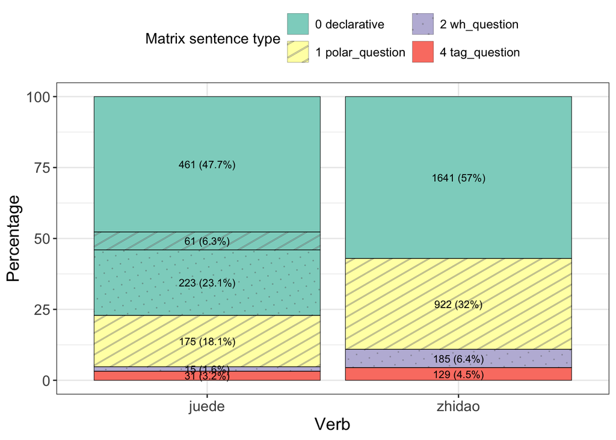

```r
ggplot(matrix_combined_summary,
       aes(x=verb,
           y=percent,
           fill=matrix_sentence_surface_type,
           pattern=matrix_sentence_type)) +
  geom_col_pattern(
    color = "black",
    linewidth = 0.2,
    pattern_fill = "lightgrey",
    pattern_density = 0.1,
    pattern_size = 0.2,
    pattern_spacing = 0.03,
    pattern_alpha = 0.4
  )+
  scale_pattern_manual(
    values = c(
      "0 declarative" = "none",
      "1 polar_question" = "stripe",
      "2 wh_question" = "circle",
      "4 tag_question" = "none"),
    name="Matrix sentence type",
    guide=guide_legend(nrow=2)
    )+
  geom_text(aes(label=paste0(count, " (", round(percent, 1), "%)")),
            position = position_stack(vjust = 0.5),
            color = "black",
            size = 3)+
  theme_bw()+
  scale_fill_brewer(palette = "Set3",
                    name="Matrix sentence type",
                    guide=guide_legend(nrow=2)) +
  theme(legend.position = "top",
        axis.title.x = element_text(size = 14),
        axis.text.x = element_text(size = 12),
        axis.text.y = element_text(size = 12),
        strip.text = element_text(size = 12),
        strip.text.x = element_text(size=12),
        legend.text = element_text(size=10),
        legend.title = element_text(size=12),
        axis.title.y = element_text(size = 14))+
  labs(x="Verb",
       y="Percentage")
```

```r
embedded_combined_summary <- matrix_embedded_sentence_combined.data %>%
  group_by(verb, embedded_sentence_surface_type) %>%
  summarize(count = n()) %>%
  ungroup() %>%
  group_by(verb) %>%
  mutate(percent = count/sum(count) * 100) %>%
  ungroup()
```

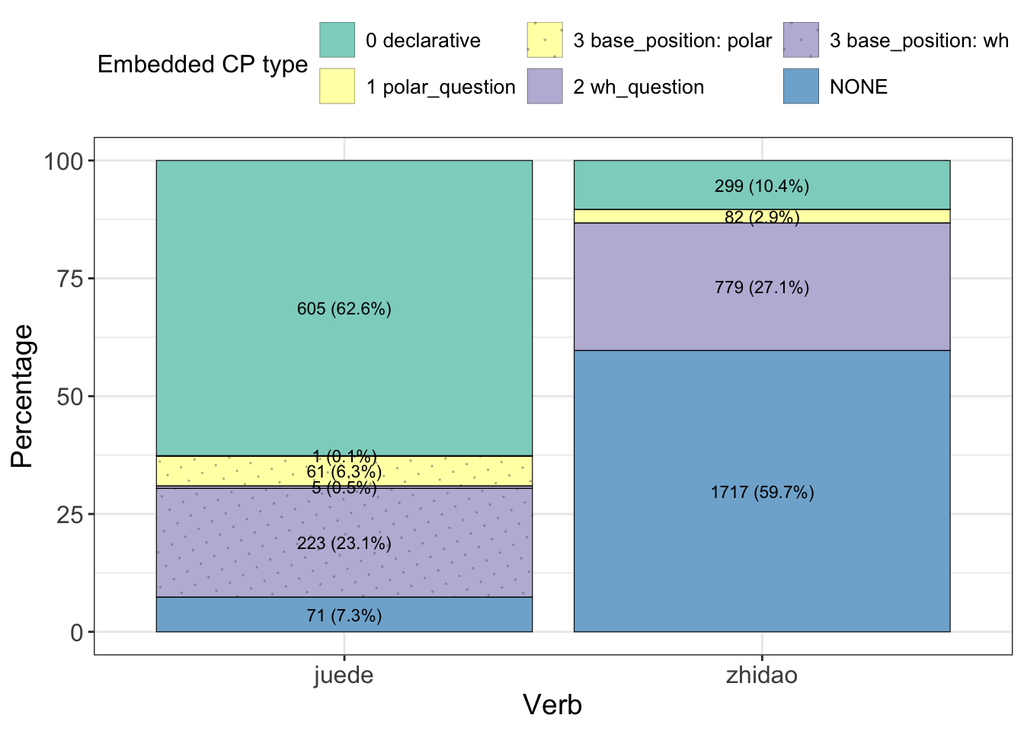

```r
ggplot(embedded_combined_summary %>%
         mutate(embedded_sentence_surface_type = fct_relevel(
           embedded_sentence_surface_type,
           "0 declarative",
           "1 polar_question",
           "3 base_position: polar",
           "2 wh_question",
           "3 base_position: wh",
           "NONE"
         )),
       aes(x=verb,
           y=percent,
           fill=embedded_sentence_surface_type,
           pattern=embedded_sentence_surface_type)) +
  geom_col_pattern(
    color = "black",
    linewidth = 0.2,
    pattern_fill = "lightgrey",
    pattern_density = 0.1,
    pattern_size = 0.2,
    pattern_spacing = 0.03,
    pattern_alpha = 0.4
  )+
  scale_pattern_manual(
    values = c(
      "0 declarative" = "none",
      "1 polar_question" = "none",
      "2 wh_question" = "none",
      "3 base_position: polar" = "circle",
      "3 base_position: wh" = "circle",
      "NONE" = "none"),
    name="Embedded CP type",
    guide=guide_legend(nrow=2)
  )+
  geom_text(aes(label=paste0(count, " (", round(percent, 1), "%)")),
            position = position_stack(vjust = 0.5),
            color = "black",
            size = 3)+
  theme_bw()+
  scale_fill_manual(
    values = c(
      "0 declarative" = "#8DD3C7",  # 1
      "1 polar_question" = "#FFFFB3",  # 2
      "3 base_position: polar" = "#FFFFB3",
      "2 wh_question" = "#BEBADA", # 3
      "3 base_position: wh" = "#BEBADA",
      "NONE" = "#80B1D3" # 5
    ),
    name = "Embedded CP type",
    guide=guide_legend(nrow=2)
  )+
  theme(legend.position = "top",
        axis.title.x = element_text(size = 14),
        axis.text.x = element_text(size = 12),
        axis.text.y = element_text(size = 12),
        strip.text = element_text(size = 12),
        strip.text.x = element_text(size=12),
        legend.text = element_text(size=10),
        legend.title = element_text(size=12),
        axis.title.y = element_text(size = 14))+
  labs(x="Verb",
       y="Percentage")
```

Here, we are combining polar and wh questions together into a single “interrogative” category.

```r
matrix_embedded_sentence_combined_alt.data <- matrix_embedded_sentence_combined.data %>%
  mutate(embedded_sentence_surface_type = case_when(embedded_sentence_surface_type %in% c("1 polar_question", "2 wh_question") ~ "interrogative",
                                                     embedded_sentence_surface_type %in% c("3 base_position: polar", "3 base_position: wh") ~ "interrogative: base",
                                                     embedded_sentence_surface_type == "0 declarative" ~ "non-interrogative",
                                                     TRUE ~ embedded_sentence_surface_type))

embedded_combined_alt_summary <- matrix_embedded_sentence_combined_alt.data %>%
  group_by(verb, embedded_sentence_surface_type) %>%
  summarize(count = n()) %>%
  ungroup() %>%
  group_by(verb) %>%
  mutate(percent = count/sum(count) * 100) %>%
  ungroup()
```

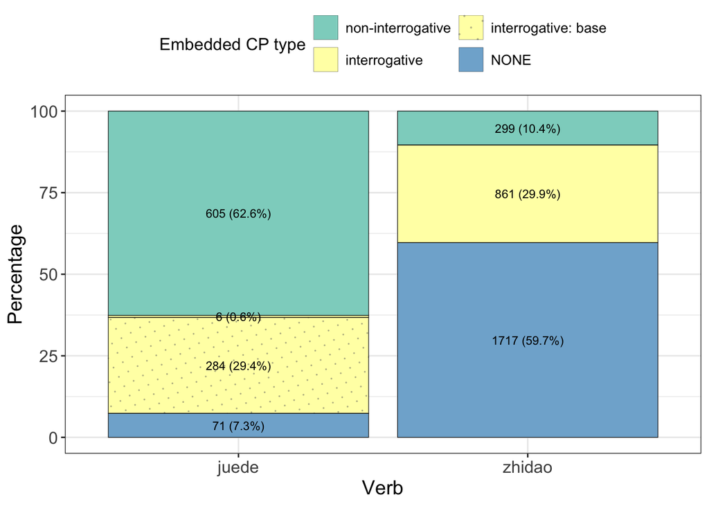

```r
ggplot(embedded_combined_alt_summary %>%
         mutate(embedded_sentence_surface_type = fct_relevel(
           embedded_sentence_surface_type,
           "non-interrogative",
           "interrogative",
           "interrogative: base",
           "NONE"
         )),
       aes(x=verb,
           y=percent,
           fill=embedded_sentence_surface_type,
           pattern=embedded_sentence_surface_type)) +
  geom_col_pattern(
    color = "black",
    linewidth = 0.2,
    pattern_fill = "lightgrey",
    pattern_density = 0.1,
    pattern_size = 0.2,
    pattern_spacing = 0.03,
    pattern_alpha = 0.4
  )+
  scale_pattern_manual(
    values = c(
      "non-interrogative" = "none",
      "interrogative" = "none",
      "interrogative: base" = "circle",
      "NONE" = "none"),
    name="Embedded CP type",
    guide=guide_legend(nrow=2)
  )+
  geom_text(aes(label=paste0(count, " (", round(percent, 1), "%)")),
            position = position_stack(vjust = 0.5),
            color = "black",
            size = 3)+
  theme_bw()+
  scale_fill_manual(
    values = c(
      "non-interrogative" = "#8DD3C7",  # 1
      "interrogative" = "#FFFFB3",  # 2
      "interrogative: base" = "#FFFFB3",
      "NONE" = "#80B1D3" # 5
    ),
    name = "Embedded CP type",
    guide=guide_legend(nrow=2)
  )+
  theme(legend.position = "top",
        axis.title.x = element_text(size = 14),
        axis.text.x = element_text(size = 12),
        axis.text.y = element_text(size = 12),
        strip.text = element_text(size = 12),
        strip.text.x = element_text(size=12),
        legend.text = element_text(size=10),
        legend.title = element_text(size=12),
        axis.title.y = element_text(size = 14))+
  labs(x="Verb",
       y="Percentage")
```

### 3.4.2 matrix and embedded clause types combined with the type of embedded content

Here, we combine the annotation for the type of embedded content to further specify the type of embedded content when it is not an embedded CP. In addition, for tag questions that have the target verb in the tag, they are labeled as “0 No” for embedded content and “4 tag_question” for matrix sentence type. For this type of tag questions, the embedded clause type tracks the sentence type of preceding host sentence since they may be analyzed as slifting/topicalization. We first include these sentences in the analysis with other embedded clause.

```r
matrix_embedded_combined.data <- embedded_content.data %>%
  left_join(matrix_embedded_sentence_combined.data, by=c("verb", "id")) %>%
  drop_na()

matrix_embedded_combined_summary <- matrix_embedded_combined.data %>%
  mutate(embedded_content_type = if_else(embedded_content_type == "0 No", "NONE", embedded_content_type),
         embedded_sentence_surface_type = if_else(embedded_sentence_surface_type =="NONE" & embedded_content_type %in% c("NONE", "others"), embedded_content_type, embedded_sentence_surface_type)) %>%
  group_by(verb, embedded_sentence_surface_type) %>%
  summarize(count = n()) %>%
  ungroup() %>%
  group_by(verb) %>%
  mutate(percent = count/sum(count) * 100) %>%
  ungroup()
```

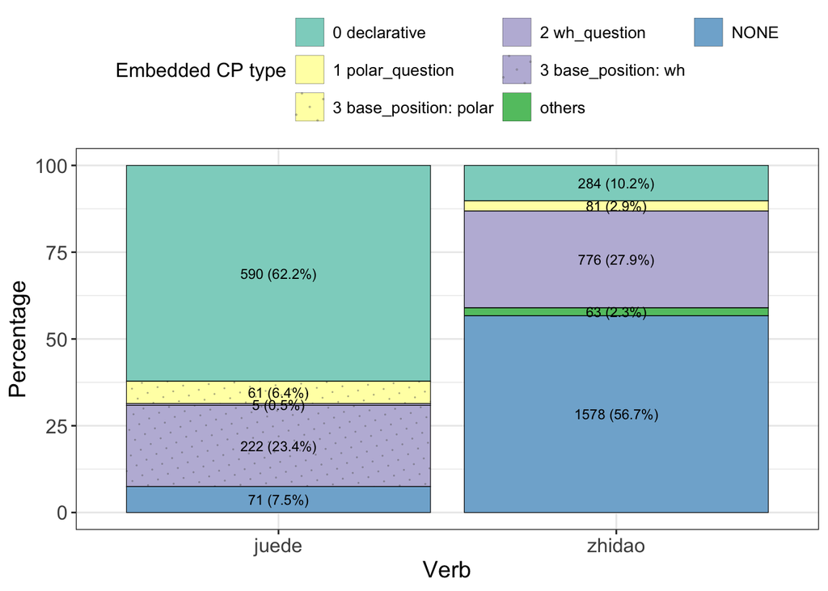

```r
ggplot(matrix_embedded_combined_summary %>%
         mutate(embedded_sentence_surface_type = fct_relevel(
           embedded_sentence_surface_type,
           "0 declarative",
           "1 polar_question",
           "3 base_position: polar",
           "2 wh_question",
           "3 base_position: wh",
           "others",
           "NONE"
         )),
       aes(x=verb,
           y=percent,
           fill=embedded_sentence_surface_type,
           pattern=embedded_sentence_surface_type)) +
  geom_col_pattern(
    color = "black",
    linewidth = 0.2,
    pattern_fill = "lightgrey",
    pattern_density = 0.1,
    pattern_size = 0.2,
    pattern_spacing = 0.03,
    pattern_alpha = 0.4
  )+
  scale_pattern_manual(
    values = c(
      "0 declarative" = "none",
      "1 polar_question" = "none",
      "2 wh_question" = "none",
      "3 base_position: polar" = "circle",
      "3 base_position: wh" = "circle",
      "others" = "none",
      "NONE" = "none"),
    name="Embedded CP type",
    guide=guide_legend(nrow=3)
  )+
  geom_text(aes(label=paste0(count, " (", round(percent, 1), "%)")),
            position = position_stack(vjust = 0.5),
            color = "black",
            size = 3)+
  theme_bw()+
  scale_fill_manual(
    values = c(
      "0 declarative" = "#8DD3C7",  # 1
      "1 polar_question" = "#FFFFB3",  # 2
      "3 base_position: polar" = "#FFFFB3",
      "2 wh_question" = "#BEBADA", # 3
      "3 base_position: wh" = "#BEBADA",
      "others" = "#62C370",
      "NONE" = "#80B1D3" # 5
    ),
    name = "Embedded CP type",
    guide=guide_legend(nrow=3)
  )+
  theme(legend.position = "top",
        axis.title.x = element_text(size = 14),
        axis.text.x = element_text(size = 12),
        axis.text.y = element_text(size = 12),
        strip.text = element_text(size = 12),
        strip.text.x = element_text(size=12),
        legend.text = element_text(size=10),
        legend.title = element_text(size=12),
        axis.title.y = element_text(size = 14))+
  labs(x="Verb",
       y="Percentage")
```

Here, we group polar questions and wh questions into a single “interrogative” category and separate the host sentences of the tag questions from other embedded clauses.

```r
matrix_embedded_combined_alt_summary <- matrix_embedded_combined.data %>%
  mutate(embedded_sentence_surface_type = if_else(embedded_content_type == "0 No" & matrix_sentence_type == "4 tag_question", "tag", embedded_sentence_surface_type)) %>%
  filter(embedded_sentence_surface_type != "tag") %>%  # filter out tag questions
  mutate(embedded_content_type = if_else(embedded_content_type == "0 No", "NONE", embedded_content_type),
         embedded_sentence_surface_type = if_else(embedded_sentence_surface_type =="NONE" & embedded_content_type %in% c("NONE", "others"), embedded_content_type, embedded_sentence_surface_type)) %>%
  mutate(embedded_sentence_surface_type = case_when(embedded_sentence_surface_type %in% c("1 polar_question", "2 wh_question") ~ "interrogative",
                                                    embedded_sentence_surface_type %in% c("3 base_position: polar", "3 base_position: wh") ~ "interrogative: base",
                                                    embedded_sentence_surface_type == "0 declarative" ~ "non-interrogative",
                                                    TRUE ~ embedded_sentence_surface_type)) %>% # group wh and polar questions into interrogative
  group_by(verb, embedded_sentence_surface_type) %>%
  summarize(count = n()) %>%
  ungroup() %>%
  group_by(verb) %>%
  mutate(percent = count/sum(count) * 100) %>%
  ungroup()
```

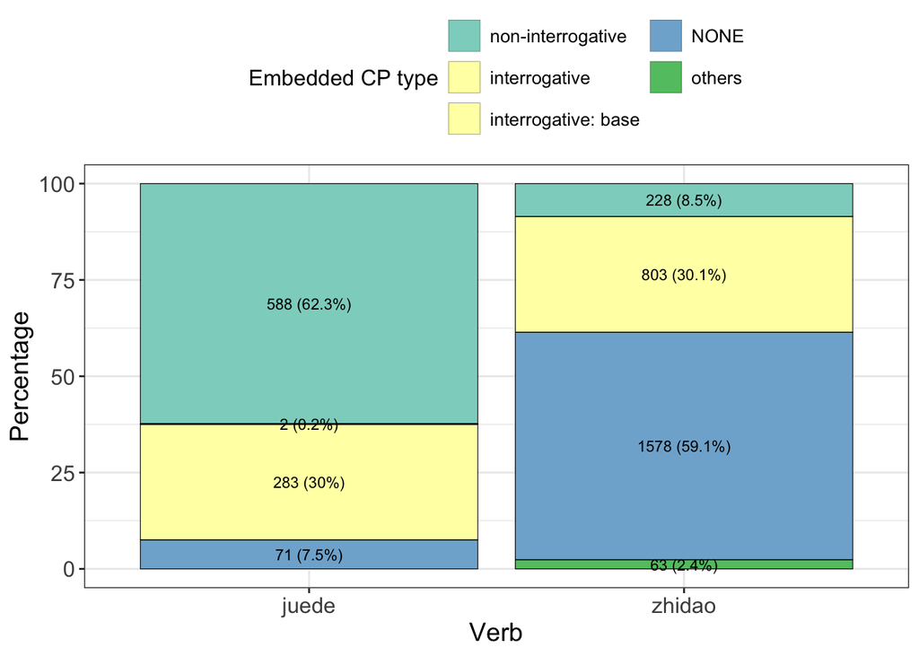

```r
ggplot(matrix_embedded_combined_alt_summary %>%
         mutate(embedded_sentence_surface_type = fct_relevel(
           embedded_sentence_surface_type,
           "non-interrogative",
           "interrogative",
           "interrogative: base",
           "NONE"
         )),
       aes(x=verb,
           y=percent,
           fill=embedded_sentence_surface_type,
           pattern=embedded_sentence_surface_type)) +
  geom_col_pattern(
    color = "black",
    linewidth = 0.2,
    pattern_fill = "lightgrey",
    pattern_density = 0.1,
    pattern_size = 0.2,
    pattern_spacing = 0.03,
    pattern_alpha = 0.4
  )+
  scale_pattern_manual(
    values = c(
      "non-interrogative" = "none",
      "interrogative" = "none",
      "interrogtaive: base" = "circle",
      "others" = "none",
      "NONE" = "none"),
    name="Embedded CP type",
    guide=guide_legend(nrow=3)
  )+
  geom_text(aes(label=paste0(count, " (", round(percent, 1), "%)")),
            position = position_stack(vjust = 0.5),
            color = "black",
            size = 3)+
  theme_bw()+
  scale_fill_manual(
    values = c(
      "non-interrogative" = "#8DD3C7",  # 1
      "interrogative" = "#FFFFB3",  # 2
      "interrogative: base" = "#FFFFB3",
      "others" = "#62C370",
      "NONE" = "#80B1D3" # 5
    ),
    name = "Embedded CP type",
    guide=guide_legend(nrow=3)
  )+
  theme(legend.position = "top",
        axis.title.x = element_text(size = 14),
        axis.text.x = element_text(size = 12),
        axis.text.y = element_text(size = 12),
        strip.text = element_text(size = 12),
        strip.text.x = element_text(size=12),
        legend.text = element_text(size=10),
        legend.title = element_text(size=12),
        axis.title.y = element_text(size = 14))+
  labs(x="Verb",
       y="Percentage")
```

## 3.5 matrix negation

```r
matrix_negation.data <- clean_data %>%
  select(c(id, verb, matrix_negation_e, matrix_negation_j1, matrix_negation_g)) %>%
  rowwise() %>%
  mutate(
    agreement = {
      vals <- c_across(matrix_negation_e:matrix_negation_g)
      vals <- vals[!is.na(vals)]
      if_else(length(unique(vals)) == 1, "same", "diff")
    },
    agreed_negation_type = {
      vals <- c_across(matrix_negation_e:matrix_negation_g)
      vals <- vals[!is.na(vals)]
      if_else(agreement == "same", vals[1], NA_character_)
    }
  ) %>%
  ungroup() %>%
  filter(agreement == "same") %>%
  select(!c(agreement, matrix_negation_e, matrix_negation_j1, matrix_negation_g)) %>%
  rename(negation_type = agreed_negation_type)

matrix_negation_summary <- matrix_negation.data %>%
  mutate(negation = if_else(negation_type == "0 no negation", "No", "Yes")) %>%
  group_by(verb, negation) %>%
  summarize(count = n()) %>%
  ungroup() %>%
  group_by(verb) %>%
  mutate(percent = count/sum(count) * 100) %>%
  ungroup()
```

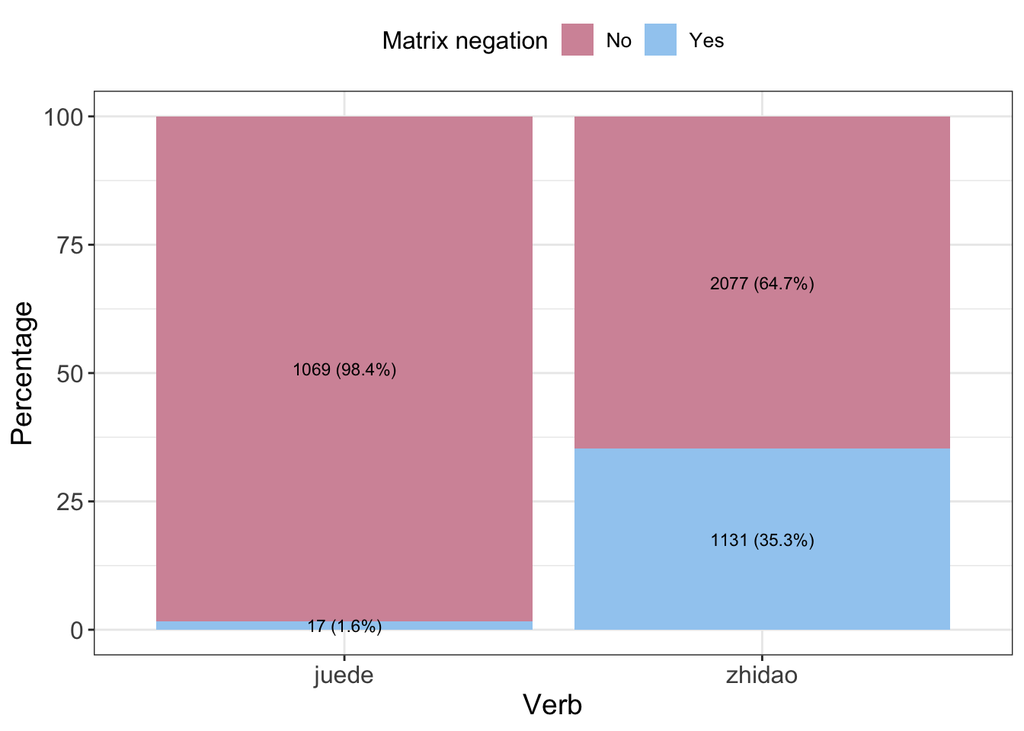

```r
ggplot(matrix_negation_summary,
       aes(x=verb,
           y=percent,
           fill=negation)) +
  geom_col()+
  geom_text(aes(label=paste0(count, " (", round(percent, 1), "%)")),
            position = position_stack(vjust = 0.5),
            color = "black",
            size = 3)+
  theme_bw()+
  scale_fill_manual(values = c("No"="#D496A7", "Yes"="#A1CDF1"),
                    name="Matrix negation") +
  theme(legend.position = "top",
        axis.title.x = element_text(size = 14),
        axis.text.x = element_text(size = 12),
        axis.text.y = element_text(size = 12),
        strip.text = element_text(size = 12),
        strip.text.x = element_text(size=12),
        legend.text = element_text(size=10),
        legend.title = element_text(size=12),
        axis.title.y = element_text(size = 14))+
  labs(x="Verb",
       y="Percentage")
```

## 3.6 sentence-final particle

```r
particle.data <- clean_data %>%
  select(c(id, verb,
           ma_particle_e, ma_particle_j, ma_particle_p)) %>%
  rowwise() %>%
  mutate(
    particle_agreement = {
      vals <- c_across(ma_particle_e:ma_particle_p)
      vals <- vals[vals != "" & !is.na(vals)]
      if_else(length(unique(vals)) == 1, "same", "diff")
      },
    agreed_particle = {
      vals <- c_across(ma_particle_e:ma_particle_p)
      vals <- vals[!is.na(vals)]
      if_else(particle_agreement == "same", vals[1], NA_character_)}
    ) %>%
  ungroup() %>%
  filter(particle_agreement == "same") %>%
  select(!c(particle_agreement, ma_particle_e, ma_particle_j, ma_particle_p)) %>%
  rename(particle_ma = agreed_particle)
```

### 3.6.1 sentence-final particle and matrix sentence type combined

Here, we are looking at the proportion of matrix polar questions that have a sentence-final particle *ma*.

```r
particle_matrix_sentence.data <- matrix_sentence.data %>%
  left_join(particle.data, by = c("id", "verb")) %>%
  drop_na()

particle_matrix_sentence_summary <- particle_matrix_sentence.data %>%
  filter(matrix_sentence_type == "1 polar_question") %>%
  group_by(verb, particle_ma) %>%
  summarize(count = n()) %>%
  ungroup() %>%
  group_by(verb) %>%
  mutate(percent = count/sum(count) * 100) %>%
  ungroup()
```

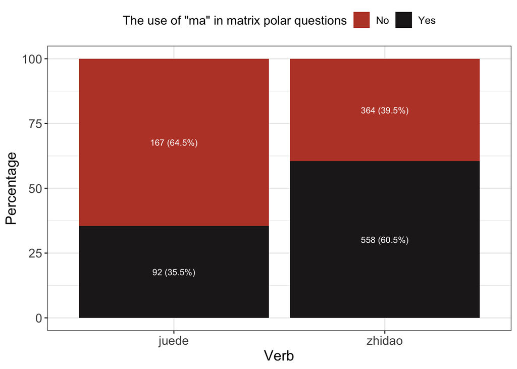

```r
ggplot(particle_matrix_sentence_summary,
       aes(x=verb,
           y=percent,
           fill=particle_ma)) +
  geom_col()+
  geom_text(aes(label=paste0(count, " (", round(percent, 1), "%)")),
            position = position_stack(vjust = 0.5),
            color = "white",
            size = 3)+
  theme_bw()+
  scale_fill_manual(values = c("Yes"= "#231F20", "No"="#BB4430"),
                    name="The use of \"ma\" in matrix polar questions") +
  theme(legend.position = "top",
        axis.title.x = element_text(size = 14),
        axis.text.x = element_text(size = 12),
        axis.text.y = element_text(size = 12),
        strip.text = element_text(size = 12),
        strip.text.x = element_text(size=12),
        legend.text = element_text(size=10),
        legend.title = element_text(size=12),
        axis.title.y = element_text(size = 14))+
  labs(x="Verb",
       y="Percentage")
```

### 3.6.2 sentence-final particle and embedded sentence type combined

When the embedded clause contains a polar construction (e.g., A-not-A or *haishi*) or a wh-phrase, it can either take a matrix scope or an local scope in the embedded clause. Therefore, these sentences are potentially interrogative. As argued in Huang et al. (2022), the sentence-final particle *ma* for polar questions are incompatible with wh-questions and polar questions with A-not-A or *haishi*, and thus if these potentially interrogative sentences have a sentence-final *ma*, it indicates that the wh-phrase or the polar question is interpreted locally in the embedded clause, and the verb is responsive (or regative). Thus, here, we are looking at the proportion of potentially interrogative embedded clauses that have a sentence-final particle *ma*.

```r
particle_embedded_sentence.data <- embedded_sentence.data %>%
  left_join(particle.data, by = c("id", "verb")) %>%
  drop_na() %>%
  mutate(potentially_interrogative = if_else(embedded_sentence_type %in% c("1 polar_question", "2 wh_question", "3 base_position"), "yes", "no"))

particle_embedded_sentence_summary <- particle_embedded_sentence.data %>%
  filter(potentially_interrogative == "yes") %>%
  group_by(verb,particle_ma) %>%
  summarize(count = n()) %>%
  ungroup() %>%
  group_by(verb) %>%
  mutate(percent = count/sum(count) * 100) %>%
  ungroup()
```

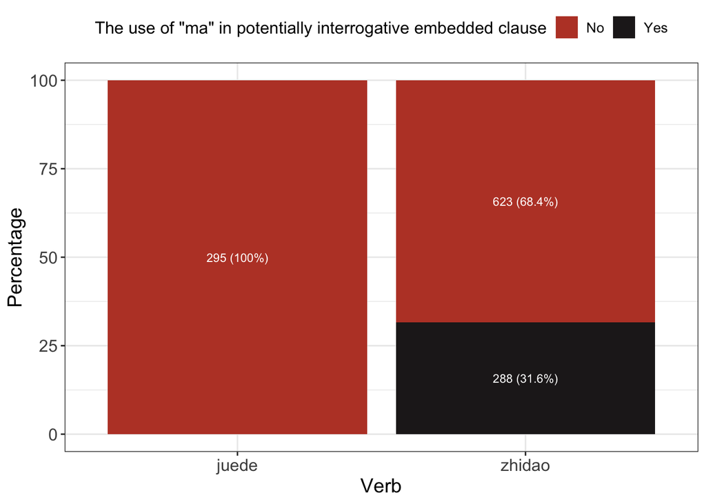

```r
ggplot(particle_embedded_sentence_summary,
       aes(x=verb,
           y=percent,
           fill=particle_ma)) +
  geom_col()+
  geom_text(aes(label=paste0(count, " (", round(percent, 1), "%)")),
            position = position_stack(vjust = 0.5),
            color = "white",
            size = 3)+
  theme_bw()+
  scale_fill_manual(values = c("Yes"= "#231F20", "No"="#BB4430"),
                    name="The use of \"ma\" in potentially interrogative embedded clause") +
  theme(legend.position = "top",
        axis.title.x = element_text(size = 14),
        axis.text.x = element_text(size = 12),
        axis.text.y = element_text(size = 12),
        strip.text = element_text(size = 12),
        strip.text.x = element_text(size=12),
        legend.text = element_text(size=10),
        legend.title = element_text(size=12),
        axis.title.y = element_text(size = 14))+
  labs(x="Verb",
       y="Percentage")
```

## 3.7 speech acts

We are using syntactic structures as proxies for different speech acts. Only data that annotators agreed on all categories (i.e., matrix subject type, matrix and embedded sentence types, and negation) are included.

```r
subject_sentence.data <- clean_data %>%
  select(c(id, verb,
           subject_j1, subject_j2,
           sentence_type_e, sentence_type_g, sentence_type_c, sentence_type_j3,
           embedded_sentence_type_e, embedded_sentence_type_g, embedded_sentence_type_c, embedded_sentence_type_j3,
           matrix_negation_e, matrix_negation_j1, matrix_negation_g)) %>%
  mutate(subject_agreement = if_else(subject_j1 == subject_j2, "same", "diff"),
    across(embedded_sentence_type_e:embedded_sentence_type_j3, ~ if_else(.x == "", "NONE", .x))
  ) %>%
  filter(subject_agreement=="same") %>%
  select(!c(subject_agreement, subject_j1)) %>%
  rowwise() %>%
  mutate(
    matrix_n_filled = sum(c_across(sentence_type_e:sentence_type_j3) != "" & !is.na(c_across(sentence_type_e:sentence_type_j3))),
    matrix_agreement = {
      vals <- c_across(sentence_type_e:sentence_type_j3)
      vals <- vals[vals != "" & !is.na(vals)]
      if_else(matrix_n_filled == 2 && length(unique(vals)) == 1, "same", "diff")
    },
    embedded_agreement = {
      vals <- c_across(embedded_sentence_type_e:embedded_sentence_type_j3)
      vals <- vals[!is.na(vals)]
      if_else(length(unique(vals)) == 1, "same", "diff")
    },
    negation_agreement = {
      vals <- c_across(matrix_negation_e:matrix_negation_g)
      vals <- vals[!is.na(vals)]
      if_else(length(unique(vals)) == 1, "same", "diff")
    },
    agreed_sentence_type = {
      vals <- c_across(sentence_type_e:sentence_type_j3)
      vals <- vals[vals != "" & !is.na(vals)]
      vals[1]
    },
    agreed_embedded_sentence_type = {
      vals <- c_across(embedded_sentence_type_e:embedded_sentence_type_j3)
      vals <- vals[!is.na(vals)]
      if_else(embedded_agreement == "same", vals[1], NA_character_)
    },
    agreed_negation_type = {
      vals <- c_across(matrix_negation_e:matrix_negation_g)
      vals <- vals[!is.na(vals)]
      if_else(negation_agreement == "same", vals[1], NA_character_)
    }
  ) %>%
  ungroup() %>%
  filter(matrix_agreement == "same" & embedded_agreement == "same" & negation_agreement == "same") %>%
  select(!c(matrix_n_filled, matrix_agreement,sentence_type_e, sentence_type_g, sentence_type_c, sentence_type_j3,
            embedded_agreement, embedded_sentence_type_e, embedded_sentence_type_g, embedded_sentence_type_c, embedded_sentence_type_j3,
            matrix_negation_e, matrix_negation_j1, matrix_negation_g,
            negation_agreement)) %>%
  rename(subject_type = subject_j2,
         matrix_sentence_type = agreed_sentence_type,
         embedded_sentence_type = agreed_embedded_sentence_type,
         negation_type = agreed_negation_type)
```

Here, we are combining the type of embedded content and then exclude sentences where the verb is followed by an NP, part of a relative clause, or is incomplete. There are 108 sentences being dropped due to the disagreement between the type of embedded content. 72 sentences are further filtered out with an embedded content in the “others” category.

```r
subject_sentence_content.data <- embedded_content.data %>%
  left_join(subject_sentence.data, by=c("id", "verb")) %>%
  drop_na() %>%
  filter(embedded_content_type != "others")
```

Here is the summary table with all combinations of matrix subject type, matrix sentence type, embedded sentence type, and negation.

```r
subject_sentence_summary <- subject_sentence_content.data %>%
  mutate(negation = if_else(negation_type == "0 no negation", "0 no negation", "1 yes negation")) %>%
  group_by(verb, subject_type, matrix_sentence_type, embedded_sentence_type, negation) %>%
  summarize(count=n()) %>%
  ungroup() %>%
  arrange(desc(count))

subject_sentence_summary
```

| verb | subject_type | matrix_sentence_type | embedded_sentence_type | negation | count |
| --- | --- | --- | --- | --- | --- |
| zhidao | 2 second_person | 1 polar_question | 2 wh_question | 0 no negation | 357 |
| juede | 1 first_person | 0 declarative | 0 declarative | 0 no negation | 305 |
| zhidao | 0 dropped | 0 declarative | NONE | 1 yes negation | 294 |
| zhidao | 1 first_person | 0 declarative | NONE | 0 no negation | 262 |
| zhidao | 2 second_person | 1 polar_question | NONE | 0 no negation | 212 |
| juede | 2 second_person | 2 wh_question | 3 base_position | 0 no negation | 211 |
| zhidao | 1 first_person | 0 declarative | NONE | 1 yes negation | 170 |
| zhidao | 0 dropped | 1 polar_question | NONE | 0 no negation | 125 |
| juede | 2 second_person | 1 polar_question | 0 declarative | 0 no negation | 96 |
| zhidao | 0 dropped | 0 declarative | NONE | 0 no negation | 93 |

[output cut: 104 more lines]

Below are the syntactic combinations that we are considering:

- **(I) don’t know/think**: first person or dropped subject, matrix declarative, no embedded, negation
  - e.g., 我不知道 I don’t know. 不知道 Don’t know
  - possibly direct assertion
- **I know/think P**: first person subject, matrix declarative, embedded declarative, no negation
  - e.g., 我觉得该睡觉了 I think it is time for bed. 我知道它是一只猫 I know it is a cat.
  - possibly indirect assertion
- **You (don’t) know/think P**: second person subject, matrix declarative, embedded declarative, no/yes negation
  - e.g., 你觉得该睡觉了 You think it is time for bed. 你知道它是一只猫 You know it is a cat.
  - possibly direct assertion
- **do you know/think WH/Q**: second person subject, matrix polar, embedded wh, no negation
  - e.g., 你知道他是谁吗？Do you know who he is? (structurally: You know he is who?)
  - possibly direct (or indirect) question, depending on the answer
- **WH/Q you know/think: base**: second person subject, matrix wh, embedded base position, no negation
  - e.g., 你觉得他是谁？Who do you think he is? (structurally: You think he is who?)
  - e.g., 你觉得是不是该睡觉了？Do you think it is time for bed or not? (structurally: You think it is or it is not time for bed)
  - possibly indirect question, depending on the question
- **WH do you think/know P**: second person subject, matrix wh, embedded declarative, no negation
  - e.g., 你为什么觉得今天会下雨？Why do you think it will rain today? 你怎么知道今天会下雨？How do you know it will rain today?
  - direct question
- **do you know/think P**: second person subject, matrix polar, embedded declarative, no negation
  - e.g., 你觉得该睡觉了吗？Do you think it is time for bed? 你知道它是一只猫吗？Do you know it is a cat?
  - possibly direct (or indirect) question, depending on the answer
- **(you) know/think?**: second person or dropped subject, matrix polar, no embedded, no negation
  - e.g., 你觉得吗？Do you think? 知不知道？Do (you) know?
  - direct question
- **(I) know/think**: first person or dropped subject, matrix declarative, no embedded, no negation
  - e.g., 我知道 I know. 知道 Know
  - direct assertion
- **tag question**: matrix tag question
  - e.g., 今天下雨了，知道吗？It rained today, you know? 你知道今天下雨了，对吧？You knew it rained today, right?
  - direct question
- **third person**: matrix subject is a third person pronoun or an NP (regardless of sentence type and negation)
  - e.g., 他觉得今天下雨了 He thought it rained today 他不知道今天下雨了吗？ Did he not know it rained today?

```r
syntactic_frames.data <- subject_sentence_content.data %>%
  mutate(negation = if_else(negation_type == "0 no negation", "0 no negation", "1 yes negation")) %>%
  mutate(syntactic_frame = case_when(
    subject_type %in% c("1 first_person", "0 dropped") & matrix_sentence_type == "0 declarative" & embedded_sentence_type == "NONE" & negation == "1 yes negation" ~ "(i) don't know/think",
    subject_type %in% c("1 first_person") & matrix_sentence_type == "0 declarative" & embedded_sentence_type == "0 declarative" & negation == "0 no negation" ~ "i think/know P",
    subject_type == "2 second_person" & matrix_sentence_type == "0 declarative" & embedded_sentence_type == "0 declarative" ~ "you (don't) think/know P",
    subject_type == "2 second_person" & matrix_sentence_type == "1 polar_question" & embedded_sentence_type %in% c("1 polar_question", "2 wh_question") & negation == "0 no negation" ~ "do you know/think WH/Q",
    subject_type == "2 second_person" & matrix_sentence_type %in% c("1 polar_question", "2 wh_question") & embedded_sentence_type == "3 base_position" & negation == "0 no negation" ~ "WH/Q you think/know: base",
    subject_type == "2 second_person" & matrix_sentence_type == "2 wh_question" & embedded_sentence_type == "0 declarative" & negation == "0 no negation" ~ "WH do you think/know P",
    subject_type == "2 second_person" & matrix_sentence_type == "1 polar_question" & embedded_sentence_type == "0 declarative" & negation == "0 no negation" ~ "do you know/think P",
    subject_type %in% c("0 dropped", "2 second_person") & matrix_sentence_type == "1 polar_question" & embedded_sentence_type == "NONE" & negation == "0 no negation" ~ "(you) know/think?",
    subject_type %in% c("1 first_person", "0 dropped") & matrix_sentence_type == "0 declarative" & embedded_sentence_type == "NONE" & negation == "0 no negation" ~ "(i) know/think",
    matrix_sentence_type == "4 tag_question" ~ "tag question",
    subject_type == "3 third/NP" ~ "third person",
    TRUE ~ "others"))

syntactic_frames_summary <- syntactic_frames.data %>%
  group_by(verb, syntactic_frame) %>%
  summarize(count = n()) %>%
  ungroup() %>%
  group_by(verb) %>%
  mutate(percent = count/sum(count) * 100) %>%
  ungroup() %>%
  mutate(syntactic_frame=fct_relevel(syntactic_frame,
                                "do you know/think WH/Q",
                                "WH/Q you think/know: base",
                                "WH do you think/know P",
                                "do you know/think P",
                                "i think/know P",
                                "you (don't) think/know P",
                                "(i) don't know/think",
                                "(i) know/think",
                                "(you) know/think?",
                                "tag question",
                                "third person",
                                "others"))
```

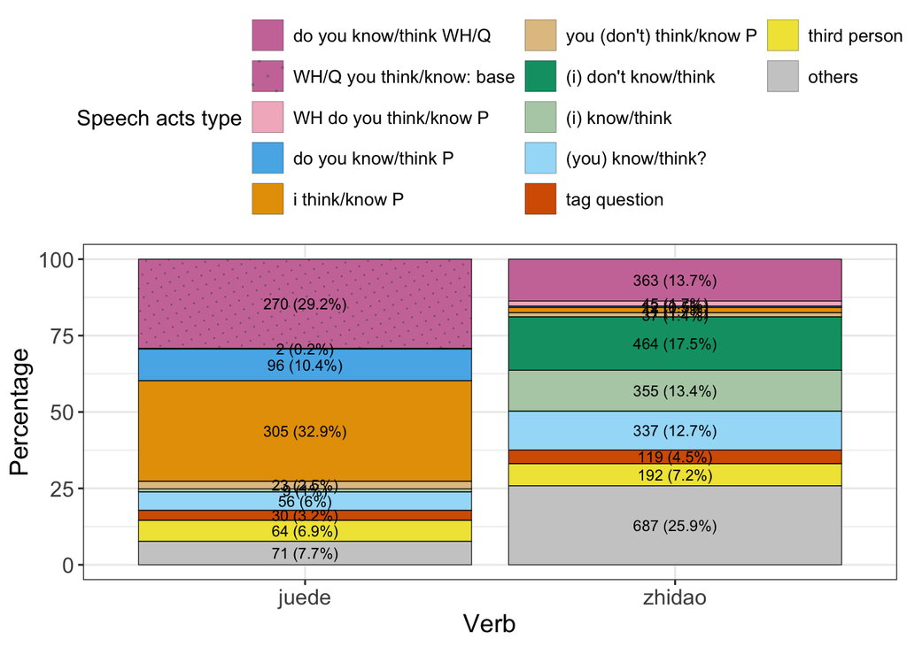

```r
ggplot(syntactic_frames_summary,
       aes(x=verb,
           y=percent,
           fill=syntactic_frame,
           pattern=syntactic_frame)) +
  geom_col_pattern(
    color = "black",
    linewidth = 0.2,
    pattern_fill = "lightgrey",
    pattern_density = 0.1,
    pattern_size = 0.2,
    pattern_spacing = 0.03,
    pattern_alpha = 0.6
  )+
  scale_pattern_manual(
    values = c(
      "do you know/think WH/Q" = "none",
      "WH/Q you think/know: base" = "circle",
      "WH do you think/know P" = "none",
      "do you know/think P" = "none",
      "you (don't) think/know P" = "none",
      "i think/know P" = "none",
      "(i) don't know/think" = "none",
      "(i) know/think" = "none",
      "(you) know/think?" = "none",
      "tag question" = "none",
      "third person" = "none",
      "others" = "none"),
    name="Speech acts type",
    guide=guide_legend(nrow=5)
  )+
  geom_text(aes(label=paste0(count, " (", round(percent, 1), "%)")),
            position = position_stack(vjust = 0.5),
            color = "black",
            size = 3)+
  theme_bw()+
  scale_fill_manual(
    values = c(
      "do you know/think WH/Q" = "#CC79A7", # purple
      "WH/Q you think/know: base" = "#CC79A7",
      "WH do you think/know P" = "#F2B7C6",
      "do you know/think P" = "#56B4E9",  # blue # light blue #6E8894
      "i think/know P" = "#E69F00", # orange
      "you (don't) think/know P"= "#E2C391",
      "(i) don't know/think" = "#009E73", # green
      "(i) know/think" = "#B4CEB3",
      "(you) know/think?" = "#A4DDF8", # light yellow #F6E27F
      "tag question" = "#D55E00",
      "third person" = "#F0E442", # yellow
      "others" = "grey80"
    ),
    name="Speech acts type",
    guide=guide_legend(nrow=5)
  ) +
  theme(legend.position = "top",
        axis.title.x = element_text(size = 14),
        axis.text.x = element_text(size = 12),
        axis.text.y = element_text(size = 12),
        strip.text = element_text(size = 12),
        strip.text.x = element_text(size=12),
        legend.text = element_text(size=10),
        legend.title = element_text(size=12),
        axis.title.y = element_text(size = 14))+
  labs(x="Verb",
       y="Percentage")
```

Here are some exploratory analysis in terms what could be in the “others” category:

- **you (don’t) think/know Q/WH**: second person subject, matrix declarative, embedded polar or wh questions, no/yes negation
  - e.g., 你(不)知道什么时候会下雨 You (don’t) know when it will rain.
  - possibly direct assertion
- **you (don’t) think/know**: second person subject, matrix declarative, embedded NONE, no/yes negation
  - e.g., 你(不)知道 You don’t know 你觉得 You think
  - possibly direct assertion
- **i (don’t) think/know Q/WH**: first person subject, matrix declarative, embedded polar or wh questions, no/yes negation
  - e.g., 我(不)知道什么时候会下雨 I (don’t) know when it will rain.
  - possibly direct assertion
- **(don’t) think/know Q/WH**: dropped subject, matrix declarative, embedded polar or wh questions, no/yes negation
  - e.g., (不)知道怎么做 (Don’t) know what to do.
  - possibly direct assertion

```r
other_syntactic_frames.data <- syntactic_frames.data %>%
  filter(syntactic_frame=="others") %>%
  mutate(syntactic_frame = case_when(
    subject_type == "2 second_person" & matrix_sentence_type == "0 declarative" & embedded_sentence_type %in% c("1 polar_qustion", "2 wh_question") ~ "you (don't) think/know Q/WH",
    subject_type == "2 second_person" & matrix_sentence_type == "0 declarative" & embedded_sentence_type == "NONE" ~ "you (don't) think/know",
    subject_type == "1 first_person" & matrix_sentence_type == "0 declarative" & embedded_sentence_type %in% c("1 polar_question","2 wh_question") ~ "i (don't) think/know Q/WH",
    subject_type == "0 dropped" & matrix_sentence_type == "0 declarative" & embedded_sentence_type %in% c("1 polar_question","2 wh_question") ~ "(don't) think/know Q/WH",
    TRUE ~ "others"))

other_syntactic_frames_summary <- other_syntactic_frames.data %>%
  group_by(verb, syntactic_frame) %>%
  summarize(count = n()) %>%
  ungroup() %>%
  group_by(verb) %>%
  mutate(percent = count/sum(count) * 100) %>%
  ungroup()

other_syntactic_frames_summary
```

| verb | syntactic_frame | count | percent |
| --- | --- | --- | --- |
| juede | i (don't) think/know Q/WH | 2 | 2.816901 |
| juede | others | 66 | 92.957746 |
| juede | you (don't) think/know | 3 | 4.225352 |
| zhidao | (don't) think/know Q/WH | 91 | 13.245997 |
| zhidao | i (don't) think/know Q/WH | 151 | 21.979622 |
| zhidao | others | 279 | 40.611354 |
| zhidao | you (don't) think/know | 131 | 19.068413 |
| zhidao | you (don't) think/know Q/WH | 35 | 5.094614 |

Similar to before, we are group polar and wh questions into a single “interrogative” category.

```r
subject_sentence_alt_summary <- subject_sentence_content.data %>%
  mutate(negation = if_else(negation_type == "0 no negation", "0 no negation", "1 yes negation"),
         matrix_sentence_type = if_else(matrix_sentence_type %in% c("1 polar_question", "2 wh_question"), "interrogative", matrix_sentence_type),
         embedded_sentence_type = if_else(embedded_sentence_type %in% c("1 polar_question", "2 wh_question"), "interrogative", embedded_sentence_type)) %>%
  group_by(verb, subject_type, matrix_sentence_type, embedded_sentence_type, negation) %>%
  summarize(count=n()) %>%
  ungroup() %>%
  arrange(desc(count))

subject_sentence_alt_summary
```

| verb | subject_type | matrix_sentence_type | embedded_sentence_type | negation | count |
| --- | --- | --- | --- | --- | --- |
| zhidao | 2 second_person | interrogative | interrogative | 0 no negation | 368 |
| juede | 1 first_person | 0 declarative | 0 declarative | 0 no negation | 305 |
| zhidao | 0 dropped | 0 declarative | NONE | 1 yes negation | 294 |
| juede | 2 second_person | interrogative | 3 base_position | 0 no negation | 270 |
| zhidao | 1 first_person | 0 declarative | NONE | 0 no negation | 262 |
| zhidao | 2 second_person | interrogative | NONE | 0 no negation | 257 |
| zhidao | 1 first_person | 0 declarative | NONE | 1 yes negation | 170 |
| zhidao | 0 dropped | interrogative | NONE | 0 no negation | 128 |
| juede | 2 second_person | interrogative | 0 declarative | 0 no negation | 98 |
| zhidao | 0 dropped | 0 declarative | NONE | 0 no negation | 93 |

[output cut: 75 more lines]

```r
speech_acts.data <- syntactic_frames.data %>%
  mutate(speech_act = case_when(syntactic_frame == "(i) don't know/think" ~ "idk",
                                syntactic_frame == "i think/know P" ~ "indirect assertion",
                                syntactic_frame %in% c("you (don't) think/know", "you (don't) think/know P", "you (don't) think/know Q/WH","(i) know/think", "(don't) think/know Q/WH","i (don't) think/know Q/WH","i (don't) think/know Q/WH") ~ "direct assertion",
                                syntactic_frame == "WH/Q you think/know: base" ~ "indirect question",
                                syntactic_frame %in% c("do you know/think WH/Q", "do you know/think P", "tag question", "(you) know/think?", "WH do you think/know P") ~ "direct question",
                                TRUE ~ syntactic_frame))


speech_acts_summary <- speech_acts.data %>%
  group_by(verb, speech_act) %>%
  summarize(count = n()) %>%
  ungroup() %>%
  group_by(verb) %>%
  mutate(percent = count/sum(count) * 100) %>%
  ungroup() %>%
  mutate(speech_act=fct_relevel(speech_act,
                                "direct assertion",
                                "indirect assertion",
                                "direct question",
                                "indirect question",
                                "idk",
                                "third person",
                                "others"))
```

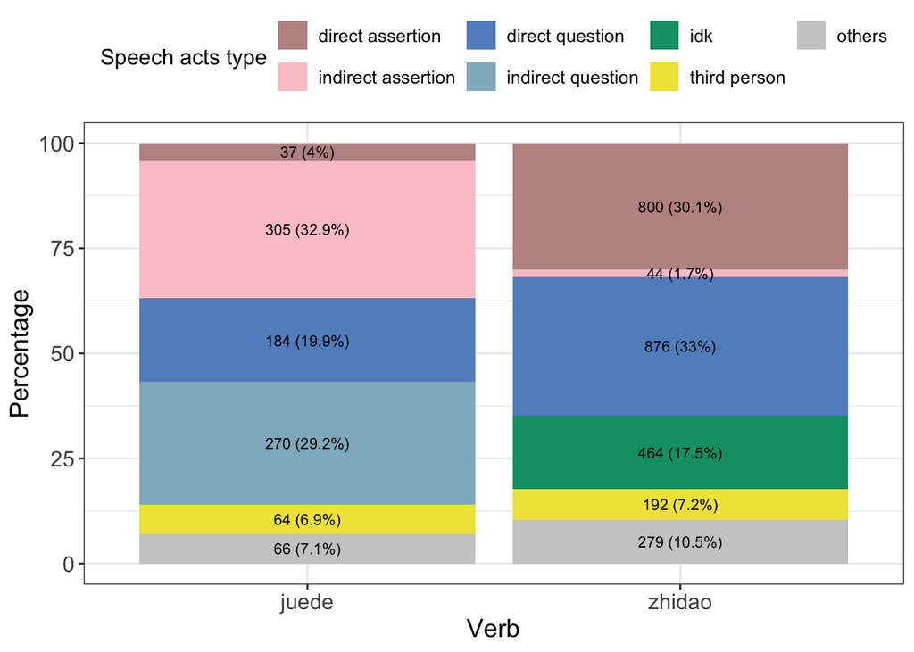

```r
ggplot(speech_acts_summary,
       aes(x=verb,
           y=percent,
           fill=speech_act,
           pattern=speech_act)) +
  geom_col()+
  geom_text(aes(label=paste0(count, " (", round(percent, 1), "%)")),
            position = position_stack(vjust = 0.5),
            color = "black",
            size = 3)+
  theme_bw()+
  scale_fill_manual(
    values = c(
      "idk" = "#009E73", # green
      "direct assertion" = "#BD9391",
      "indirect assertion" = "#FAC8CD",
      "direct question" = "#6290C8",
      "indirect question" = "#91B7C7",
      "third person" = "#F0E442", # yellow
      "others" = "grey80"
    ),
    name="Speech acts type",
    guide=guide_legend(nrow=2)
  ) +
  theme(legend.position = "top",
        axis.title.x = element_text(size = 14),
        axis.text.x = element_text(size = 12),
        axis.text.y = element_text(size = 12),
        strip.text = element_text(size = 12),
        strip.text.x = element_text(size=12),
        legend.text = element_text(size=10),
        legend.title = element_text(size=12),
        axis.title.y = element_text(size = 14))+
  labs(x="Verb",
       y="Percentage")
```